# day2_2

**Updates on genomic selection**

Day 2: Genomic selection under the genotype-by-environment interaction

**Saulo Chaves**

Assistant Professor

Data Science for Plant Breeding Lab

Piracicaba, September 2<sup>nd</sup>

[figure not shown]

[figure not shown]

# Practical session

## The dataset

[figure not shown]

[G2F](https://www.genomes2fields.org/home/)

## Phenotypic data

```r
library(tidyverse)

dat = readRDS("../Data/G2F.RDS")
str(dat)
```

```
'data.frame':   85949 obs. of  7 variables:
 $ gen      : chr  "B37/C103" "B37/H95" "B73/MO17" "B73/PHG35" ...
 $ year     : int  2014 2014 2014 2014 2014 2014 2014 2014 2014 2014 ...
 $ loc      : chr  "GAH1" "GAH1" "GAH1" "GAH1" ...
 $ env      : chr  "GAH1_2014" "GAH1_2014" "GAH1_2014" "GAH1_2014" ...
 $ blue     : num  4.69 5.98 6.29 9.73 8.05 ...
 $ std.error: num  0.828 0.828 0.828 0.828 0.828 ...
 $ wt       : num  1.91 1.91 1.91 1.91 1.91 ...
```

## Phenotypic data

**Código**

```r
ggplot(data = as.data.frame(table(dat$gen, dat$env)),
       aes(x = Var2, y = Var1, fill = as.factor(Freq))) +
  geom_tile(aes(alpha = as.factor(Freq))) +
  theme_minimal() +
  theme(axis.text = element_blank(), legend.title = element_blank(),
        legend.position = 'top') +
  scale_fill_manual(values = c('#b2bc63','#10342d'), labels = c("Abscent", "Present")) +
  scale_alpha_manual(values = c(.6, 1), labels = c("Abscent", "Present")) +
  labs(x = "Environment (Year-Location combination)", y = "Hybrid")
```

[figure not shown]

## Genomic data

```r
geno.code = readRDS(file = "../Data/mrk_filtered.RDS")
str(geno.code)
```

```
 int [1:5899, 1:2105] 1 0 0 1 1 1 1 0 0 0 ...
 - attr(*, "dimnames")=List of 2
  ..$ : chr [1:5899] "01CSI6/LH287" "01DIB2/LH287" "01DIB2/PHP02" "2369/DK3IIH6" ...
  ..$ : chr [1:2105] "S1_1007742" "S1_1020677" "S1_2018002" "S1_2275970" ...
```

```r
any(is.na(geno.code))
```

```
[1] FALSE
```

## Data management

Filtering for didactic purposes!

```r
dat = droplevels(dat[which(dat$year > 2021 & dat$loc %in% c("GAH1","IAH1","IAH2","ILH1", "INH1", "MNH1", "MOH1", "MOH2")),])
dat = dat[which(dat$gen %in% rownames(geno.code)),]
set.seed(7)
dat = dat[which(dat$gen %in% sample(unique(dat$gen),150)),]
geno.code = geno.code[which(rownames(geno.code) %in% dat$gen),]
all(unique(dat$gen) %in% rownames(geno.code))
```

```
[1] TRUE
```

## Data management

Working dataset

**Código**

```r
ggplot(data = dat, aes(
  x = reorder(env, blue),
  y = reorder(gen, blue),
  fill = blue
)) +
  geom_tile() +
  theme_minimal() +
  theme(axis.text.y = element_blank(), axis.text.x = element_text(angle = 90),
        legend.position = "top", legend.title = element_blank()) +
  scale_fill_viridis_c(option = "inferno") +
  labs(x = paste("Environments: ", length(unique(dat$env))),
       y = paste("Hybrid: ", length(unique(dat$gen))))
```

[figure not shown]

## GRM

$$\boldsymbol{G} = \frac{\boldsymbol{\dot{W}}\boldsymbol{\dot{W}}^\prime}{2\sum_m p_m \left(1-p_m\right)}$$

```r
library(AGHmatrix)
Gmat = Gmatrix(SNPmatrix = geno.code, method = "VanRaden")
```

```
Initial data:
    Number of Individuals: 150
    Number of Markers: 2105

Missing data check:
    Total SNPs: 2105
     0 SNPs dropped due to missing data threshold of 0.5
    Total of: 2105  SNPs

MAF check:
    No SNPs with MAF below 0

Heterozigosity data check:
    No SNPs with heterozygosity, missing threshold of =  0

Summary check:
    Initial:  2105 SNPs
    Final:  2105  SNPs ( 0  SNPs removed)

Completed! Time = 0.27  seconds
```

## GRM

**Código**

```r
library(ComplexHeatmap)
library(circlize)
col_fun = colorRamp2(c(-0.2, 0, 1.5), c("blue4", "white", "green4"))

Heatmap(
  Gmat,
  col = col_fun,
  show_row_names = F,
  show_column_names = F,
  heatmap_legend_param = list(title = "IBS")
)
```

[figure not shown]

## GRM

[interactive chart not shown]

## Multi-environment GS model

**Reaction norm model via RKHS (Reproducing Kernel Hilbert Space)**

$$\bar{\boldsymbol y} = \boldsymbol 1 \mu + \boldsymbol Z_e \boldsymbol e + \boldsymbol Z_g \boldsymbol g + \boldsymbol Z_{ge} \boldsymbol {ge} + \boldsymbol \varepsilon$$

- $\boldsymbol e \to$ Fixed effect of environment
- $\boldsymbol g \to$ Random main genetic effect
  - $\boldsymbol g \sim \mathcal N \left(\boldsymbol 0, \boldsymbol K_g \sigma^2_g\right)$
- $\boldsymbol {ge} \to$ Random effect of the genotype-by-environment interaction
  - $\boldsymbol {ge} \sim \mathcal N \left(\boldsymbol 0, \boldsymbol K_{ge} \sigma^2_{ge}\right)$
- $\varepsilon_{ij} \to$ IID residual

## Multi-environment GS model

**Expanding the data frame**

```r
nrow(dat)
```

```
[1] 2027
```

```r
grid = expand.grid(
  gen = unique(dat$gen),
  env = unique(dat$env),
  stringsAsFactors = FALSE
)
dat = merge(grid, dat, by = c("gen", "env"), all.x = TRUE)
nrow(dat)
```

```
[1] 2250
```

## Multi-environment GS model

**Expanding the data frame**

**Código**

```r
ggplot(data = dat, aes(
  x = reorder(env, blue),
  y = reorder(gen, blue),
  fill = blue
)) +
  geom_tile() +
  theme_minimal() +
  theme(axis.text.y = element_blank(), axis.text.x = element_text(angle = 90),
        legend.position = "top", legend.title = element_blank(),
        text = element_text(size = 18)) +
  scale_fill_viridis_c(option = "inferno", na.value = "lightgrey") +
  labs(x = paste("Environments: ", length(unique(dat$env))),
       y = paste("Hybrid: ", length(unique(dat$gen))))
```

[figure not shown]

## Multi-environment GS model

**Incidence matrices**

```r
dat$gen = factor(dat$gen, levels = rownames(Gmat), ordered = TRUE)
dat = dat[order(dat$env, dat$gen),]
ZG = model.matrix(~-1 + gen, data = dat)
rownames(ZG) = dat$gen
colnames(ZG) = gsub("gen", "", colnames(ZG))
ZG[1:5, 1:5]
```

```
                  B37/H95 B73/TX779 BGEM-0039-N/LH244 BGEM-0063-N/LH244
B37/H95                 1         0                 0                 0
B73/TX779               0         1                 0                 0
BGEM-0039-N/LH244       0         0                 1                 0
BGEM-0063-N/LH244       0         0                 0                 1
GEMN-0096/LH244         0         0                 0                 0
                  GEMN-0096/LH244
B37/H95                         0
B73/TX779                       0
BGEM-0039-N/LH244               0
BGEM-0063-N/LH244               0
GEMN-0096/LH244                 1
```

## Multi-environment GS model

**Incidence matrices**

```r
ZE = model.matrix(~-1 + env, data = dat)
rownames(ZE) = dat$env
colnames(ZE) = gsub("env", "", colnames(ZE))
ZE[1:5,1:5]
```

```
          GAH1_2022 GAH1_2023 IAH1_2022 IAH1_2023 IAH2_2022
GAH1_2022         1         0         0         0         0
GAH1_2022         1         0         0         0         0
GAH1_2022         1         0         0         0         0
GAH1_2022         1         0         0         0         0
GAH1_2022         1         0         0         0         0
```

## Multi-environment GS model

**Kernels**:

$$\boldsymbol K_g = \boldsymbol Z_g \boldsymbol G \boldsymbol Z_g^\prime$$

```r
ZGZ = ZG %*% Gmat %*% t(ZG)
rownames(ZGZ) -> aux1
dim(ZGZ)
```

```
[1] 2250 2250
```

## Multi-environment GS model

Expanded $\boldsymbol G$ (for three environments)

**Código**

```r
aux = do.call(c, lapply(split(dat, dat$env), nrow))
submat = ZGZ[1:sum(aux[1:3]),1:sum(aux[1:3])]
col_fun = colorRamp2(c(min(submat), 0, max(submat)), c("blue4", "white", "green4"))

Heatmap(
  submat,
  show_row_dend = FALSE,
  show_row_names = FALSE,
  show_column_dend = FALSE,
  show_column_names = FALSE,
  column_split = rep(names(aux)[1:3], aux[1:3]),
  row_split = rep(names(aux)[1:3], aux[1:3]),
  col = col_fun,
  show_heatmap_legend = FALSE,
  border = TRUE,
  border_gp = gpar(col = "black", lty = 2)
)
```

[figure not shown]

## Multi-environment GS model

$$\boldsymbol K_e = \boldsymbol Z_e \boldsymbol Z_e^\prime$$

```r
ZEZ = tcrossprod(ZE)
dim(ZEZ)
```

```
[1] 2250 2250
```

## Multi-environment GS model

Only 1s and 0s!

**Código**

```r
submat = ZEZ[1:sum(aux[1:4]), 1:sum(aux[1:4])]
col_fun = colorRamp2(c(min(submat), 0, max(submat)), c("blue4", "white", "green4"))

Heatmap(
  submat,
  show_row_dend = FALSE,
  show_row_names = FALSE,
  show_column_dend = FALSE,
  show_column_names = FALSE,
  column_split = rep(names(aux)[1:4], aux[1:4]),
  row_split = rep(names(aux)[1:4], aux[1:4]),
  col = col_fun,
  show_heatmap_legend = FALSE,
  border = TRUE,
  border_gp = gpar(col = "black", lty = 2)
)
```

[figure not shown]

## Multi-environment GS model

**Kernels**:

$$\boldsymbol K_{ge} = \boldsymbol K_g \odot \boldsymbol K_e$$

```r
GEI = ZGZ * ZEZ
rownames(GEI) -> aux3
dim(GEI)
```

```
[1] 2250 2250
```

## Multi-environment GS model

**Código**

```r
submat = GEI[1:sum(aux[1:5]),1:sum(aux[1:5])]
col_fun = colorRamp2(c(min(submat), 0, max(submat)), c("blue4", "white", "green4"))

Heatmap(
  submat,
  show_row_dend = FALSE,
  show_row_names = FALSE,
  show_column_dend = FALSE,
  show_column_names = FALSE,
  column_split = rep(names(aux)[1:5], aux[1:5]),
  row_split = rep(names(aux)[1:5], aux[1:5]),
  col = col_fun,
  show_heatmap_legend = FALSE,
  border = TRUE,
  border_gp = gpar(col = "black", lty = 2)
)
```

[figure not shown]

## Multi-environment GS model

**Eigendecomposition** (efficient computation)

$$\begin{gather}
\boldsymbol K_{ge} = \boldsymbol V_{ge} \boldsymbol D_{ge} \boldsymbol V_{ge} \\
\boldsymbol K_{g} = \boldsymbol V_{g} \boldsymbol D_{g} \boldsymbol V_{g}
\end{gather}$$

```r
GEI = eigen(GEI)
rownames(GEI$vectors) = aux3
ZGZ = eigen(ZGZ)
rownames(ZGZ$vectors) = aux1
```

## Multi-environment GS model

- Lesser number of iterations required

```r
library(BGLR)
ETA = list(
  env = list(X = ZE, model = 'FIXED'),
  hyb = list(V = ZGZ$vectors, d = ZGZ$values, model = 'RKHS'),
  gei = list(V = GEI$vectors, d = GEI$values, model = 'RKHS')
)

model1 = BGLR(y = dat$blue, ETA = ETA, nIter = 12000, burnIn = 2000,
              thin = 10, verbose = TRUE, saveAt = "complete_met1_")
```

## Multi-environment GS model

**Reparameterized model**: Cholesky decomposition of $\boldsymbol G$

$$\boldsymbol G = \boldsymbol L \boldsymbol L^\prime$$

```r
L_G = t(chol(Gmat + diag(x=0.0001, nrow = nrow(Gmat))))
```

**Código**

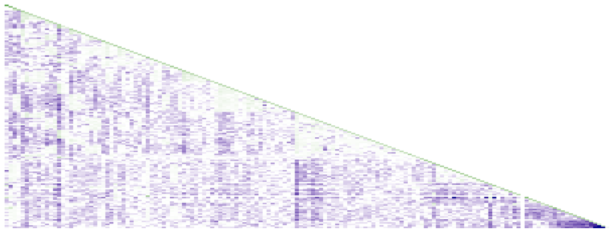

```r
Heatmap(
  L_G,
  show_row_dend = FALSE,
  show_row_names = FALSE,
  show_column_dend = FALSE,
  show_column_names = FALSE,
  row_order = rownames(L_G),
  column_order = colnames(L_G),
  col = col_fun,
  show_heatmap_legend = FALSE
)
```

## Multi-environment GS model

$$\begin{gather}
\boldsymbol X_g = \boldsymbol Z_g \times \boldsymbol L \\
\boldsymbol X_{ge} = \boldsymbol X_g:\boldsymbol Z_e
\end{gather}$$

```r
X_g = ZG %*% L_G
dim(X_g)
```

```
[1] 2250  150
```

```r
X_ge = model.matrix(~ -1 + X_g:dat$env)
dim(X_ge)
```

```
[1] 2250 2250
```

## Multi-environment GS model

$\boldsymbol X_g$:

**Código**

```r
submat = X_g[1:sum(aux[1:2]),1:50]
col_fun = colorRamp2(c(min(submat), 0, max(submat)), c("blue4", "white", "green4"))

Heatmap(
  X_g,
  show_row_dend = FALSE,
  show_row_names = FALSE,
  show_column_dend = FALSE,
  show_column_names = FALSE,
  row_order = rownames(X_g),
  column_order = colnames(X_g),
  col = col_fun,
  # row_split = rep(names(aux)[1:2], aux[1:2]),
  show_heatmap_legend = FALSE
)
```

[figure not shown]

## Multi-environment GS model

$\boldsymbol X_ge$:

[figure not shown]

## Multi-environment GS model

```r
ETA2 = list(
  env = list(X = ZE, model = 'FIXED'),
  hyb = list(X = X_g, model = 'BRR'),
  gei = list(X = X_ge, model = 'BRR')
)

model2 = BGLR(y = dat$blue, ETA = ETA2, nIter = 12000, burnIn = 2000,
             thin = 10, verbose = TRUE, saveAt = "complete_met2_")
```

## Multi-environment GS model

**Model parameters**

```r
modparam = data.frame(varE = c(model1$varE, model2$varE),
                      varG = c(model1$ETA$hyb$varU, model2$ETA$hyb$varB),
                      varGE = c(model1$ETA$gei$varU, model2$ETA$gei$varB),
                      model = c("RKHS", "CHOL (BRR)"));modparam
```

```
      varE     varG    varGE      model
1 1.882919 1.553343 1.697239       RKHS
2 1.876174 1.724512 1.703228 CHOL (BRR)
```

## Multi-environment GS model

**Model parameters**

**Código**

```r
modparam |> group_by(model) |>
  mutate(varT = varE + varG + varGE,
         PvE = varE/varT,
         PvG = varG/varT,
         PvGE = varGE/varT) |> relocate(model, .before = varE) |>
  pivot_longer(varE:PvGE) |> filter(!grepl("var", name)) |>
  ggplot(aes(x = model, y = value)) +
  geom_col(aes(fill = name), color = "black") +
  theme_bw() +
  labs(x = "Model", y = "Percentage from total variance") +
  scale_y_continuous(labels = scales::percent) +
  scale_fill_viridis_d(option="mako", labels = c("varE", "varG", "varGEI")) +
  theme(text = element_text(size = 18), legend.position = "top",
        legend.title = element_blank())
```

[figure not shown]

## Multi-environment GS model

**Predictions**

```r
res = data.frame(gen = dat$gen, env = dat$env, blue = dat$blue,
                 pred1 = model1$yHat, pred2 = model2$yHat)
```

**Código**

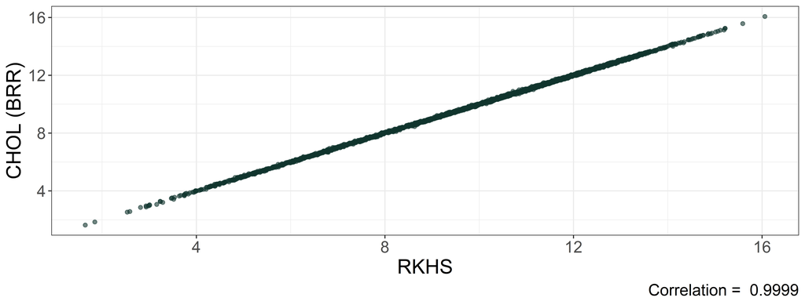

```r
ggplot(data = res, aes(x = pred1, y = pred2)) +
  geom_point(alpha = .6, color = '#10342d') +
  labs(x = "RKHS", y = "CHOL (BRR)",
       caption = paste("Correlation = ", round(cor(res$pred2, res$pred1), 4))) +
  theme_bw() +
  theme(text = element_text(size = 18))
```

## Multi-environment GS model

**Convergence**

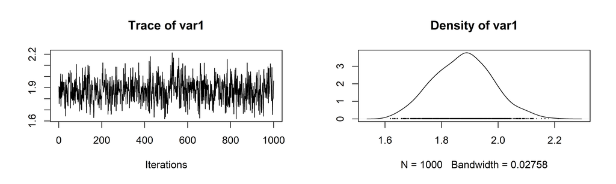

```r
library(coda)
trace_varE = read.table("../complete_met2_varE.dat")[,1]
trace_varG = read.table("../complete_met2_ETA_hyb_varU.dat")[,1]
trace_varGEI = read.table("../complete_met2_ETA_gei_varU.dat")[,1]
varE_chain = mcmc(trace_varE[201:length(trace_varE)])
varG_chain = mcmc(trace_varG[201:length(trace_varG)])
varGEI_chain = mcmc(trace_varGEI[201:length(trace_varGEI)])
plot(varE_chain)
```

## Multi-environment GS model

**Convergence**

```r
effectiveSize(varE_chain)
```

```
    var1
534.0472
```

```r
effectiveSize(varG_chain)
```

```
var1
1000
```

```r
effectiveSize(varGEI_chain)
```

```
   var1
229.046
```

```r
geweke.diag(varE_chain)
```

```
Fraction in 1st window = 0.1
Fraction in 2nd window = 0.5

   var1
-0.6276
```

```r
geweke.diag(varG_chain)
```

```
Fraction in 1st window = 0.1
Fraction in 2nd window = 0.5

  var1
-1.196
```

```r
geweke.diag(varGEI_chain)
```

```
Fraction in 1st window = 0.1
Fraction in 2nd window = 0.5

  var1
-0.852
```

## Cross-validations

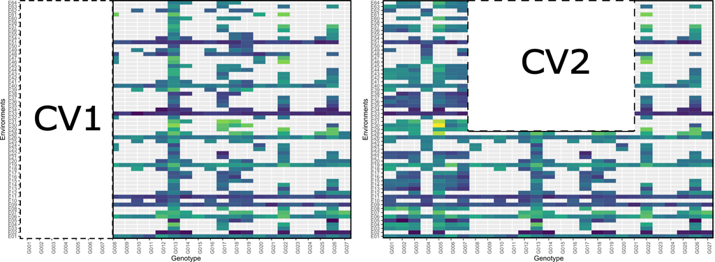

```r
nfolds = 5
nrept = 5
```

## Cross-validations

**CV2: Sparse-testing**

```r
sets = list()
i = 1
repeat{
  set.seed(987 * i)
  sets[[i]] = sample(rep(1:nfolds, length.out = nrow(dat)))
  i = i + 1
  if(i > nrept) break
}
cvdata = lapply(sets, function(x){
  cvdata = dat
  cvdata$set = x
  return(cvdata)
})
for (i in 1:length(cvdata)) cvdata[[i]]$rept = i
```

## Cross-validations

**CV2: Sparse-testing**

```r
cv2 = lapply(cvdata, function(x){
  res.list = list()
  for (i in unique(x$set)) {

    yNA = x$blue
    yNA[x$set == i] = NA

    mod_cv = BGLR(y = yNA, ETA = ETA2, nIter = 8000, burnIn = 1000,
                  thin = 10, verbose = FALSE, saveAt = "modCV")
    unlink(list.files(pattern = "modCV"))

    res.list[[i]] = data.frame(
      gen = x$gen,
      env = x$env,
      blue = x$blue,
      set = x$set,
      yNA = yNA,
      yhat = mod_cv$yHat
    ) |> filter(set == i)

  }
  res.list
})

cv2 = lapply(cv2, function(x) do.call(rbind, x))
```

## Cross-validations

**CV1: Untested genotypes**

```r
sets = list()
i = 1
repeat{
  set.seed(7 * i)
  sets[[i]] = sample(rep(1:nfolds, length.out = nlevels(dat$gen)))
  i = i + 1
  if(i > nrept) break
}
cvdata = lapply(sets, function(x){
  cvdata = dat
  aux = data.frame(gen = levels(dat$gen), set = x)
  cvdata$set = aux$set[match(cvdata$gen, aux$gen)]
  return(cvdata)
})
for (i in 1:length(cvdata)) cvdata[[i]]$rept = i
```

## Cross-validations

**CV1: Untested genotypes**

```r
cv1 = lapply(cvdata, function(x){
  res.list = list()
  for (i in unique(x$set)) {

    yNA = x$blue
    yNA[x$set == i] = NA

    mod_cv = BGLR(y = yNA, ETA = ETA2, nIter = 8000, burnIn = 1000,
                  thin = 10, verbose = FALSE, saveAt = "modCV")
    unlink(list.files(pattern = "modCV"))

    res.list[[i]] = data.frame(
      gen = x$gen,
      env = x$env,
      blue = x$blue,
      set = x$set,
      yNA = yNA,
      yhat = mod_cv$yHat
    ) |> filter(set == i)

  }
  res.list
})
cv1 = lapply(cv1, function(x) do.call(rbind, x))
```

## Cross-validations

```r
res_cv1 = lapply(cv1, function(x){
  x |> reframe(rmspe = sqrt(mean((blue - yhat)^2, na.rm = T)),
               pa = cor(blue, yhat),
               .by = env)
})
res_cv1
```

```
[[1]]
         env    rmspe        pa
1  GAH1_2022 1.889566 0.1702812
2  IAH1_2022 2.022620 0.4196013
3  IAH2_2022 3.367848 0.3187834
4  ILH1_2022 1.874160 0.2719688
5  INH1_2022 1.423681 0.4246822
6  MNH1_2022 1.558176 0.4690019
7  MOH2_2022 1.650287 0.2446381
8  GAH1_2023 2.035345 0.2008071
9  IAH1_2023 1.836036 0.6045529
10 IAH2_2023 1.221760 0.6056442
11 ILH1_2023 1.404764 0.4389203
12 INH1_2023 1.892373 0.3624826
13 MNH1_2023 1.519305 0.5680988
```

[output cut: 74 more lines]

## Cross-validations

```r
res_cv1_mean = do.call(rbind, lapply(res_cv1, function(x) reframe(x, rmspe = mean(rmspe), pa = mean(pa))))
res_cv1_mean$rept = 1:5
res_cv1_mean$CV = "CV1"
res_cv1_mean
```

```
     rmspe        pa rept  CV
1 1.762064 0.3695290    1 CV1
2 1.760595 0.3763727    2 CV1
3 1.744627 0.3872516    3 CV1
4 1.814131 0.3169716    4 CV1
5 1.740626 0.3959873    5 CV1
```

## Cross-validations

```r
res_cv2 = lapply(cv2, function(x){
  x |> reframe(rmspe = sqrt(mean((blue - yhat)^2, na.rm = T)),
               pa = cor(blue, yhat),
               .by = env)
})
res_cv2
```

```
[[1]]
         env    rmspe        pa
1  GAH1_2022 1.879606 0.2662937
2  IAH1_2022 1.797687 0.5931229
3  IAH2_2022 3.210433 0.4251466
4  ILH1_2022 1.725585 0.4573075
5  INH1_2022 1.177796 0.6625441
6  MNH1_2022 1.479689 0.5490231
7  MOH2_2022 1.530060 0.4449176
8  GAH1_2023 2.058755 0.2433487
9  IAH1_2023 1.539022 0.7588185
10 IAH2_2023 1.035859 0.7375820
11 ILH1_2023 1.244886 0.6049751
12 INH1_2023 1.613326 0.6118256
13 MNH1_2023 1.279705 0.7223321
```

[output cut: 74 more lines]

## Cross-validations

```r
res_cv2_mean = do.call(rbind, lapply(res_cv2, function(x) reframe(x, rmspe = mean(rmspe), pa = mean(pa))))
res_cv2_mean$rept = 1:5
res_cv2_mean$CV = "CV2"
res_cv2_mean
```

```
     rmspe        pa rept  CV
1 1.597330 0.5390653    1 CV2
2 1.598823 0.5373875    2 CV2
3 1.590777 0.5455875    3 CV2
4 1.590765 0.5456946    4 CV2
5 1.600633 0.5380831    5 CV2
```

## Cross-validations

**Código**

```r
rbind(res_cv1_mean, res_cv2_mean) |>
  pivot_longer(rmspe:pa) |>
  ggplot(aes(x = CV, y = value)) +
  facet_wrap(.~name, scales = "free_y", labeller = labeller(.cols = c("pa" = "Predictive ability", "rmspe" = "RMSPE")))+
  geom_boxplot(fill = "#b2bc63") +
  theme_bw() +
  theme(axis.title.y = element_blank(), text = element_text(size = 18))
```

[figure not shown]

## Cross-validations

**Código**

```r
for (i in 1:length(res_cv1)){
  res_cv1[[i]]$rept = i
  res_cv1[[i]]$CV = "CV1"
}
for (i in 1:length(res_cv2)){
  res_cv2[[i]]$rept = i
  res_cv2[[i]]$CV = "CV2"
}
rbind(
  do.call(rbind, res_cv1),
  do.call(rbind, res_cv2)
) |> pivot_longer(rmspe:pa) |>
  ggplot(aes(x = env, y = value)) +
  # facet_wrap(.~name, scales = "free_y", labeller = labeller(.cols = c("pa" = "Predictive ability", "rmspe" = "RMSPE"))) +
  facet_grid(name~CV, scales = 'free_y',
             labeller = labeller(.rows = c("pa" = "Predictive ability",
                                           "rmspe" = "RMSPE")))+
  theme_bw() +
  theme(axis.title.y = element_blank(), text = element_text(size = 14),
        axis.text.x = element_text(angle = 90, vjust = .5, hjust = 1)) +
  geom_boxplot(fill = "#b2bc63")
```

[figure not shown]

## References

Campos, G. de los, Hickey, J. M., Pong-Wong, R., Daetwyler, H. D., & Calus, M. P. L. (2013). Whole-genome regression and prediction methods applied to plant and animal breeding. *Genetics*, *193*(2), 327–345. https://doi.org/10.1534/genetics.112.143313

Jarquin, D., Crossa, J., Lacaze, X., Du Cheyron, P., Daucourt, J., Lorgeou, J., Piraux, F., Guerreiro, L., Pérez, P., Calus, M., Burgueño, J., & Campos, G. de los. (2014). A reaction norm model for genomic selection using high-dimensional genomic and environmental data. *Theoretical and applied genetics*, *127*(3), 595–607. https://doi.org/10.1007/s00122-013-2243-1

Lima, D. C., Washburn, J. D., Varela, J. I., Chen, Q., Gage, J. L., Romay, M. C., Holland, J., Ertl, D., Lopez-Cruz, M., Aguate, F. M., Campos, G. de los, Kaeppler, S., Beissinger, T., Bohn, M., Buckler, E., Edwards, J., Flint-Garcia, S., Gore, M. A., Hirsch, C. N., … Leon, N. de. (2023). Genomes to Fields 2022 Maize genotype by Environment Prediction Competition. *BMC Research Notes*, *16*(1), 148. https://doi.org/10.1186/s13104-023-06421-z

Pérez, P., & Campos, G. de los. (2014). Genome-wide regression and prediction with the BGLR statistical package. *Genetics*, *198*(2), 483–495. https://doi.org/10.1534/genetics.114.164442